# LBB6_Yvonne

Yvonne Lam

10/3/2019

# Report

Building a linear regression model to predict crime rates based on different socioeconomic variables.

## Analysis

### Data Preparation

Peek into the data.

```r
#load and check data
str(crime)
```

```
## 'data.frame':    47 obs. of  16 variables:
##  $ percent_m           : int  151 143 142 136 141 121 127 131 157 140 ...
##  $ is_south            : int  1 0 1 0 0 0 1 1 1 0 ...
##  $ mean_education      : int  91 113 89 121 121 110 111 109 90 118 ...
##  $ police_exp60        : int  58 103 45 149 109 118 82 115 65 71 ...
##  $ police_exp59        : int  56 95 44 141 101 115 79 109 62 68 ...
##  $ labour_participation: int  510 583 533 577 591 547 519 542 553 632 ...
##  $ m_per1000f          : int  950 1012 969 994 985 964 982 969 955 1029 ...
##  $ state_pop           : int  33 13 18 157 18 25 4 50 39 7 ...
##  $ nonwhites_per1000   : int  301 102 219 80 30 44 139 179 286 15 ...
##  $ unemploy_m24        : int  108 96 94 102 91 84 97 79 81 100 ...
##  $ unemploy_m39        : int  41 36 33 39 20 29 38 35 28 24 ...
##  $ gdp                 : int  394 557 318 673 578 689 620 472 421 526 ...
##  $ inequality          : int  261 194 250 167 174 126 168 206 239 174 ...
##  $ prob_prison         : num  0.0846 0.0296 0.0834 0.0158 0.0414 ...
##  $ time_prison         : num  26.2 25.3 24.3 29.9 21.3 ...
##  $ crime_rate          : int  791 1635 578 1969 1234 682 963 1555 856 705 ...
```

```r
#check for missing values
summary(crime)
```

```
##    percent_m        is_south      mean_education   police_exp60
##  Min.   :119.0   Min.   :0.0000   Min.   : 87.0   Min.   : 45.0
##  1st Qu.:130.0   1st Qu.:0.0000   1st Qu.: 97.5   1st Qu.: 62.5
##  Median :136.0   Median :0.0000   Median :108.0   Median : 78.0
##  Mean   :138.6   Mean   :0.3404   Mean   :105.6   Mean   : 85.0
##  3rd Qu.:146.0   3rd Qu.:1.0000   3rd Qu.:114.5   3rd Qu.:104.5
##  Max.   :177.0   Max.   :1.0000   Max.   :122.0   Max.   :166.0
##   police_exp59    labour_participation   m_per1000f       state_pop
##  Min.   : 41.00   Min.   :480.0        Min.   : 934.0   Min.   :  3.00
##  1st Qu.: 58.50   1st Qu.:530.5        1st Qu.: 964.5   1st Qu.: 10.00
##  Median : 73.00   Median :560.0        Median : 977.0   Median : 25.00
##  Mean   : 80.23   Mean   :561.2        Mean   : 983.0   Mean   : 36.62
##  3rd Qu.: 97.00   3rd Qu.:593.0        3rd Qu.: 992.0   3rd Qu.: 41.50
##  Max.   :157.00   Max.   :641.0        Max.   :1071.0   Max.   :168.00
##  nonwhites_per1000  unemploy_m24     unemploy_m39        gdp
##  Min.   :  2.0     Min.   : 70.00   Min.   :20.00   Min.   :288.0
##  1st Qu.: 24.0     1st Qu.: 80.50   1st Qu.:27.50   1st Qu.:459.5
##  Median : 76.0     Median : 92.00   Median :34.00   Median :537.0
##  Mean   :101.1     Mean   : 95.47   Mean   :33.98   Mean   :525.4
##  3rd Qu.:132.5     3rd Qu.:104.00   3rd Qu.:38.50   3rd Qu.:591.5
##  Max.   :423.0     Max.   :142.00   Max.   :58.00   Max.   :689.0
##    inequality     prob_prison       time_prison      crime_rate
##  Min.   :126.0   Min.   :0.00690   Min.   :12.20   Min.   : 342.0
##  1st Qu.:165.5   1st Qu.:0.03270   1st Qu.:21.60   1st Qu.: 658.5
##  Median :176.0   Median :0.04210   Median :25.80   Median : 831.0
##  Mean   :194.0   Mean   :0.04709   Mean   :26.60   Mean   : 905.1
##  3rd Qu.:227.5   3rd Qu.:0.05445   3rd Qu.:30.45   3rd Qu.:1057.5
##  Max.   :276.0   Max.   :0.11980   Max.   :44.00   Max.   :1993.0
```

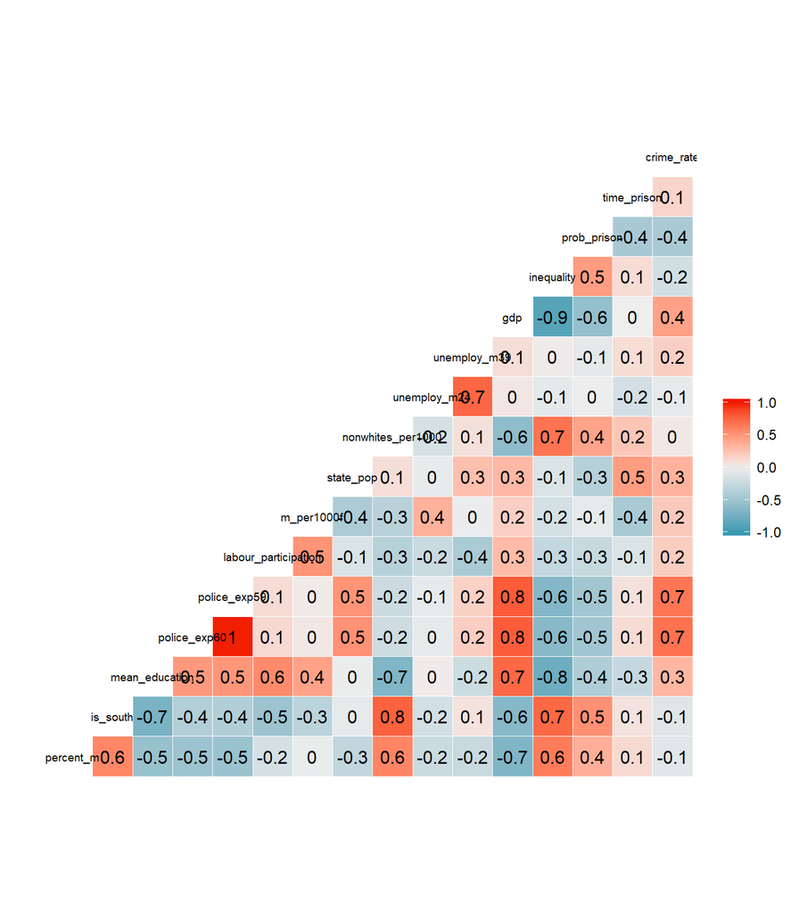

```r
#check correlations
ggcorr(crime, label = T, layout.exp = 1, cex=2.5)
```

Looking at the correlation matrix, `police_exp59` and `police_exp60` are highly correlated to crime rates at 0.7. Additionally, both variables are perfectly correlated to each other. Hence, we need to drop either of the two variables as having both will affect the significance of each predictor in the regression model.  
Other variables weakly correlated to crime rates are `prob_prison`, `gdp`, `state_pop` and `mean_education`. They could be useful predictors. Since `gdp` and `inequality` have negative high correlation as well, one of it should be dropped from the model.

Create train and test sets.

```r
set.seed(123)
sample_crime <- sample(nrow(crime), nrow(crime)*0.8)
train_crime <- crime[sample_crime,]
test_crime <- crime[-sample_crime,]

#check train and test datasets size
dim(train_crime)
dim(test_crime)
dim(crime)
```

[output not shown]

### Build base model

Base model is built with all the independent variables considered in the regression model. This will be the baseline for comparison with subsequent models. Model performance can be accessed on metrics like R squared and RMSE.

```r
#Base linear model
base_model <- lm(crime_rate ~., train_crime)
summary(base_model)
```

```
##
## Call:
## lm(formula = crime_rate ~ ., data = train_crime)
##
## Residuals:
##     Min      1Q  Median      3Q     Max
## -312.69 -115.78  -13.32  121.88  493.30
##
## Coefficients:
##                        Estimate Std. Error t value Pr(>|t|)
## (Intercept)          -8186.7507  2063.0737  -3.968 0.000701 ***
## percent_m                9.6114     4.4695   2.150 0.043322 *
## is_south               166.4722   193.6198   0.860 0.399615
## mean_education          20.6768     7.1398   2.896 0.008643 **
## police_exp60            16.2888    12.5251   1.300 0.207524
## police_exp59            -9.6516    14.1006  -0.684 0.501156
## labour_participation    -1.3948     1.8183  -0.767 0.451576
## m_per1000f               4.8237     2.5115   1.921 0.068459 .
## state_pop                0.7300     1.6283   0.448 0.658522
## nonwhites_per1000        0.2490     0.7386   0.337 0.739359
## unemploy_m24            -8.3149     4.8952  -1.699 0.104165
## unemploy_m39            17.5423    10.1738   1.724 0.099352 .
## gdp                      0.6753     1.2370   0.546 0.590899
## inequality               4.3479     2.8133   1.545 0.137166
## prob_prison          -3692.7096  2503.9762  -1.475 0.155118
## time_prison              2.5409     8.1988   0.310 0.759681
## ---
## Signif. codes:  0 '***' 0.001 '**' 0.01 '*' 0.05 '.' 0.1 ' ' 1
##
## Residual standard error: 215 on 21 degrees of freedom
## Multiple R-squared:  0.8372, Adjusted R-squared:  0.7209
## F-statistic: 7.199 on 15 and 21 DF,  p-value: 2.976e-05
```

```r
#prediction using model
predict_1 <- predict(base_model, test_crime)
#comparing actual against prediction values
data.frame(predict_1,test_crime$crime_rate)
```

```
##    predict_1 test_crime.crime_rate
## 1   663.3214                   791
## 2  1396.1760                  1635
## 6   729.5305                   682
## 20 1135.3584                  1225
## 23  702.8289                  1216
## 24  834.2943                   968
## 32  804.0054                   754
## 40 1261.7363                  1151
## 43 1341.1928                   823
## 47 1051.8213                   849
```

```r
#R squared(how correlated predicted and actual values are, the higher the better)
r_1 <- R2(predict_1, test_crime$crime_rate)

#rmse(error rate; avg diff btw predicted and actual values, the lower the better)
rmse_1 <- RMSE(predict_1, test_crime$crime_rate)
```

### Model Selection

Build more models based on model selection methods (Stepwise and best subset)

```r
#Stepwise method to choose combination with least sum of residuals squared
step_both <- step(base_model, direction = "both")
```

```
## Start:  AIC=408.45
## crime_rate ~ percent_m + is_south + mean_education + police_exp60 +
##     police_exp59 + labour_participation + m_per1000f + state_pop +
##     nonwhites_per1000 + unemploy_m24 + unemploy_m39 + gdp + inequality +
##     prob_prison + time_prison
##
##                        Df Sum of Sq     RSS    AIC
## - time_prison           1      4438  974747 406.62
## - nonwhites_per1000     1      5252  975561 406.65
## - state_pop             1      9286  979596 406.81
## - gdp                   1     13769  984078 406.98
## - police_exp59          1     21648  991957 407.27
## - labour_participation  1     27187  997497 407.48
## - is_south              1     34157 1004466 407.73
## <none>                               970309 408.45
## - police_exp60          1     78146 1048455 409.32
## - prob_prison           1    100490 1070799 410.10
## - inequality            1    110362 1080672 410.44
## - unemploy_m24          1    133312 1103621 411.22
## - unemploy_m39          1    137371 1107680 411.35
## - m_per1000f            1    170445 1140755 412.44
## - percent_m             1    213671 1183980 413.82
## - mean_education        1    387509 1357818 418.89
##
## Step:  AIC=406.62
## crime_rate ~ percent_m + is_south + mean_education + police_exp60 +
##     police_exp59 + labour_participation + m_per1000f + state_pop +
##     nonwhites_per1000 + unemploy_m24 + unemploy_m39 + gdp + inequality +
##     prob_prison
##
##                        Df Sum of Sq     RSS    AIC
## - state_pop             1     10880  985627 405.03
## - nonwhites_per1000     1     10944  985692 405.04
## - gdp                   1     18811  993558 405.33
## - labour_participation  1     27787 1002535 405.66
## - is_south              1     30219 1004966 405.75
## - police_exp59          1     32308 1007055 405.83
## <none>                               974747 406.62
## - police_exp60          1     97814 1072561 408.16
## + time_prison           1      4438  970309 408.45
```

[output cut: 106 more lines]

```
## - is_south              1     86633 1128994 400.06
## + time_prison           1     21891 1020470 400.32
## + police_exp59          1     14193 1028168 400.60
## + gdp                   1     13842 1028520 400.61
## + state_pop             1     10104 1032257 400.74
## + labour_participation  1      4544 1037818 400.94
## + nonwhites_per1000     1      1141 1041220 401.06
## - unemploy_m24          1    123647 1166008 401.25
## - unemploy_m39          1    181662 1224023 403.05
## - inequality            1    190794 1233155 403.32
## - m_per1000f            1    212529 1254890 403.97
## - prob_prison           1    221307 1263668 404.23
## - percent_m             1    255308 1297669 405.21
## - mean_education        1    394880 1437241 408.99
## - police_exp60          1   1199859 2242220 425.45
```

```r
step_both$call
```

```
## lm(formula = crime_rate ~ percent_m + is_south + mean_education +
##     police_exp60 + m_per1000f + unemploy_m24 + unemploy_m39 +
##     inequality + prob_prison, data = train_crime)
```

```r
model_2 <- lm(formula = crime_rate ~ percent_m + is_south + mean_education +
    police_exp60 + m_per1000f + unemploy_m24 + unemploy_m39 +
    inequality + prob_prison, data = train_crime)

summary(model_2)
```

```
##
## Call:
## lm(formula = crime_rate ~ percent_m + is_south + mean_education +
##     police_exp60 + m_per1000f + unemploy_m24 + unemploy_m39 +
##     inequality + prob_prison, data = train_crime)
##
## Residuals:
##    Min     1Q Median     3Q    Max
## -424.1 -108.7  -10.5  116.3  538.9
##
## Coefficients:
##                 Estimate Std. Error t value Pr(>|t|)
## (Intercept)    -7335.785   1443.801  -5.081 2.45e-05 ***
## percent_m          9.651      3.753   2.572  0.01595 *
## is_south         198.484    132.499   1.498  0.14573
## mean_education    18.636      5.827   3.198  0.00352 **
## police_exp60       9.169      1.645   5.575 6.53e-06 ***
## m_per1000f         3.600      1.534   2.346  0.02655 *
## unemploy_m24      -6.979      3.899  -1.790  0.08474 .
## unemploy_m39      19.494      8.987   2.169  0.03904 *
## inequality         3.840      1.727   2.223  0.03477 *
## prob_prison    -4171.052   1742.107  -2.394  0.02386 *
## ---
## Signif. codes:  0 '***' 0.001 '**' 0.01 '*' 0.05 '.' 0.1 ' ' 1
##
## Residual standard error: 196.5 on 27 degrees of freedom
## Multiple R-squared:  0.8251, Adjusted R-squared:  0.7668
## F-statistic: 14.15 on 9 and 27 DF,  p-value: 4.263e-08
```

```r
predict_2 <- predict(model_2, test_crime)
data.frame(predict_2,test_crime$crime_rate)
```

```
##    predict_2 test_crime.crime_rate
## 1   662.7269                   791
## 2  1391.3004                  1635
## 6   754.7942                   682
## 20 1181.2744                  1225
## 23  744.0652                  1216
## 24  872.5592                   968
## 32  751.0144                   754
## 40 1187.7246                  1151
## 43 1192.6132                   823
## 47 1160.9487                   849
```

```r
#R squared
r_2 <- R2(predict_2, test_crime$crime_rate)

#rmse
rmse_2 <- RMSE(predict_2, test_crime$crime_rate)

#Adjusted R squared of model has improved from the base model and its p-value is <0.05, hence it is statistically significant. Variable is_south has a p-value >0.05, hence we should try removing it from model.

#try removing variable is_south since it is not significant and generate another model
model_3 <- lm(formula = crime_rate ~ percent_m + mean_education +
    police_exp60 + m_per1000f + unemploy_m24 + unemploy_m39 +
    inequality + prob_prison, data = train_crime)

summary(model_3)
```

```
##
## Call:
## lm(formula = crime_rate ~ percent_m + mean_education + police_exp60 +
##     m_per1000f + unemploy_m24 + unemploy_m39 + inequality + prob_prison,
##     data = train_crime)
##
## Residuals:
##     Min      1Q  Median      3Q     Max
## -440.39 -118.46   20.14  109.33  495.59
##
## Coefficients:
##                 Estimate Std. Error t value Pr(>|t|)
## (Intercept)    -7311.156   1475.431  -4.955 3.13e-05 ***
## percent_m         11.011      3.721   2.959  0.00622 **
## mean_education    17.952      5.937   3.024  0.00530 **
## police_exp60       9.544      1.661   5.745 3.64e-06 ***
## m_per1000f         3.235      1.548   2.090  0.04586 *
## unemploy_m24      -8.676      3.813  -2.275  0.03074 *
## unemploy_m39      23.820      8.697   2.739  0.01060 *
## inequality         4.958      1.592   3.114  0.00423 **
## prob_prison    -3043.586   1605.658  -1.896  0.06839 .
## ---
## Signif. codes:  0 '***' 0.001 '**' 0.01 '*' 0.05 '.' 0.1 ' ' 1
##
## Residual standard error: 200.8 on 28 degrees of freedom
## Multiple R-squared:  0.8106, Adjusted R-squared:  0.7564
## F-statistic: 14.98 on 8 and 28 DF,  p-value: 2.909e-08
```

```r
predict_3 <- predict(model_3, test_crime)
data.frame(predict_3,test_crime$crime_rate)
```

```
##    predict_3 test_crime.crime_rate
## 1   688.2445                   791
## 2  1445.4352                  1635
## 6   723.4585                   682
## 20 1239.9879                  1225
## 23  853.2996                  1216
## 24  830.7437                   968
## 32  791.1698                   754
## 40 1096.0245                  1151
## 43 1141.1932                   823
## 47 1150.1520                   849
```

```r
#R squared
r_3 <- R2(predict_3, test_crime$crime_rate)

#rmse
rmse_3 <- RMSE(predict_3, test_crime$crime_rate)

#Adjusted R squared of model has dropped slightly, however p-value shows it is still statistically significant.
#Hence, this model is still a good fit for the data.
#As the drop in value is small and there is one less variable in the model,
#this model is simpler and should be kept for further evaluation.
```

```r
#Best subset regression
lm_all <- regsubsets(crime_rate ~., crime, nvmax=16)
crime_subset <- summary(lm_all)

which.min(crime_subset$bic)
```

```
## [1] 6
```

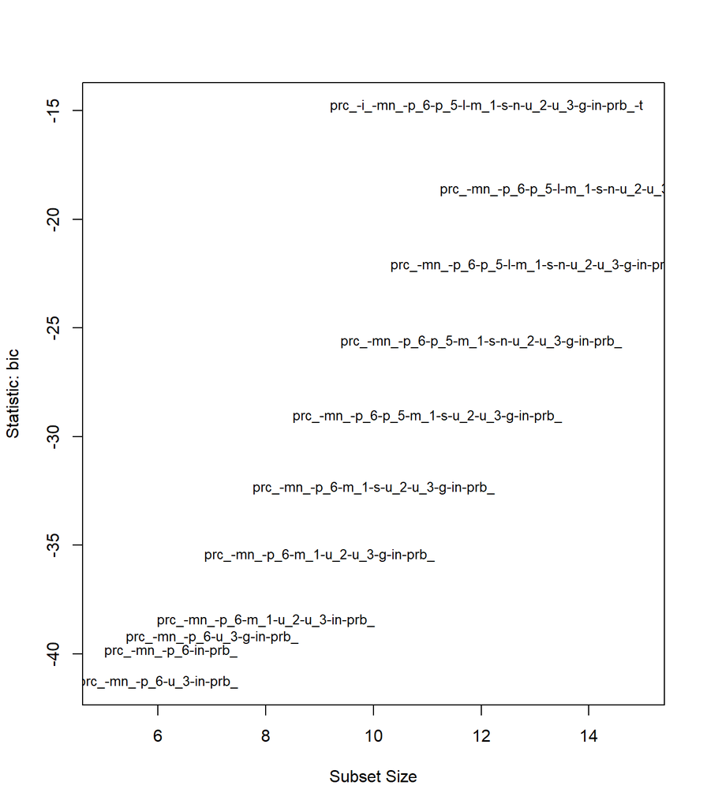

```
##                      Abbreviation
## percent_m                    prc_
## is_south                       i_
## mean_education                mn_
## police_exp60                  p_6
## police_exp59                  p_5
## labour_participation            l
## m_per1000f                    m_1
## state_pop                       s
## nonwhites_per1000               n
## unemploy_m24                  u_2
## unemploy_m39                  u_3
## gdp                             g
## inequality                     in
## prob_prison                  prb_
## time_prison                     t
```

```r
subsets(lm_all, statistic = "bic", legend = F, cex.subsets= 0.8, min.size = 5)
```

```r
model_4 <- lm(crime_rate ~ percent_m + mean_education + police_exp60 + unemploy_m39 + inequality + prob_prison, data = train_crime)
summary(model_4)
```

```
##
## Call:
## lm(formula = crime_rate ~ percent_m + mean_education + police_exp60 +
##     unemploy_m39 + inequality + prob_prison, data = train_crime)
##
## Residuals:
##     Min      1Q  Median      3Q     Max
## -465.80  -90.46  -16.84  117.76  596.46
##
## Coefficients:
##                 Estimate Std. Error t value Pr(>|t|)
## (Intercept)    -5124.115   1146.268  -4.470 0.000103 ***
## percent_m         11.923      3.920   3.041 0.004859 **
## mean_education    19.633      5.605   3.503 0.001465 **
## police_exp60      11.274      1.540   7.320 3.75e-08 ***
## unemploy_m39       9.328      5.610   1.663 0.106801
## inequality         6.001      1.644   3.650 0.000989 ***
## prob_prison    -3030.985   1718.358  -1.764 0.087934 .
## ---
## Signif. codes:  0 '***' 0.001 '**' 0.01 '*' 0.05 '.' 0.1 ' ' 1
##
## Residual standard error: 215.2 on 30 degrees of freedom
## Multiple R-squared:  0.7669, Adjusted R-squared:  0.7203
## F-statistic: 16.45 on 6 and 30 DF,  p-value: 2.705e-08
```

```r
predict_4 <- predict(model_4, test_crime)
data.frame(predict_4,test_crime$crime_rate)
```

```
##    predict_4 test_crime.crime_rate
## 1   809.0808                   791
## 2  1370.9527                  1635
## 6   731.5348                   682
## 20 1192.3250                  1225
## 23  883.0461                  1216
## 24  916.5007                   968
## 32  770.7984                   754
## 40 1110.8568                  1151
## 43 1026.3422                   823
## 47  989.3982                   849
```

```r
#R squared
r_4 <- R2(predict_4, test_crime$crime_rate)

#rmse
rmse_4 <- RMSE(predict_4, test_crime$crime_rate)

#Adjusted R squared is 0.7203 and p-value shows it is statistically significant.
#Model should be considered for further evaluation.
```

```r
#try removing variable unemploy_m39 as it seems statistically insignificant in model_4 and generate another model
model_5 <- lm(formula = crime_rate ~ percent_m + mean_education + police_exp60 + inequality + prob_prison, data = train_crime)

summary(model_5)
```

```
##
## Call:
## lm(formula = crime_rate ~ percent_m + mean_education + police_exp60 +
##     inequality + prob_prison, data = train_crime)
##
## Residuals:
##     Min      1Q  Median      3Q     Max
## -486.20  -80.52   -6.95  163.82  545.66
##
## Coefficients:
##                 Estimate Std. Error t value Pr(>|t|)
## (Intercept)    -4044.817    971.253  -4.165 0.000231 ***
## percent_m          9.656      3.779   2.555 0.015740 *
## mean_education    14.941      4.978   3.001 0.005270 **
## police_exp60      11.960      1.526   7.840 7.57e-09 ***
## inequality         5.959      1.690   3.526 0.001338 **
## prob_prison    -3275.817   1760.083  -1.861 0.072227 .
## ---
## Signif. codes:  0 '***' 0.001 '**' 0.01 '*' 0.05 '.' 0.1 ' ' 1
##
## Residual standard error: 221.2 on 31 degrees of freedom
## Multiple R-squared:  0.7454, Adjusted R-squared:  0.7044
## F-statistic: 18.16 on 5 and 31 DF,  p-value: 2.109e-08
```

```r
predict_5 <- predict(model_5, test_crime)
data.frame(predict_5, test_crime$crime_rate)
```

```
##    predict_5 test_crime.crime_rate
## 1   744.6341                   791
## 2  1315.1862                  1635
## 6   817.0401                   682
## 20 1002.3783                  1225
## 23  956.6668                  1216
## 24  798.5802                   968
## 32  698.5042                   754
## 40 1121.3438                  1151
## 43 1050.4971                   823
## 47  875.0956                   849
```

```r
#R squared
r_5 <- R2(predict_5, test_crime$crime_rate)

#rmse
rmse_5 <- RMSE(predict_5, test_crime$crime_rate)

#Adjusted R squared is 0.7044 and p-value shows it is statistically significant.
#Model should be considered for further evaluation.
```

### Compare models

Based on RMSE and R squared

```r
r_all <- c(r_1, r_2, r_3, r_4, r_5)
rmse_all <- c(rmse_1, rmse_2, rmse_3, rmse_4, rmse_5)
name <- c("Base Model", "Model 2", "Model 3", "Model 4", "Model 5")
kable(data.frame(name,"R squared" = r_all,"RMSE" = rmse_all))
```

| name | R.squared | RMSE |
| --- | --- | --- |
| Base Model | 0.2904261 | 262.5412 |
| Model 2 | 0.3726529 | 234.5569 |
| Model 3 | 0.5166513 | 198.7891 |
| Model 4 | 0.7186860 | 158.1244 |
| Model 5 | 0.6835468 | 180.1607 |

Model 4 seems like the best model amongst all as it has the highest R squared and lowest RMSE. High R squared mean the predicted values are highly correlated to actual values; the model best predicts the desired results. Also, low RMSE means model 4 has the least errors in prediction results.

### Simple diagnostic checks

Diagnostic checks are conducted on model 4 as it is the best model thus far. We assume the predicted results and the predictors have a linear relationship when building the model. However, this may not be true. Hence, diagnostic checks are needed for checking the assumptions made.

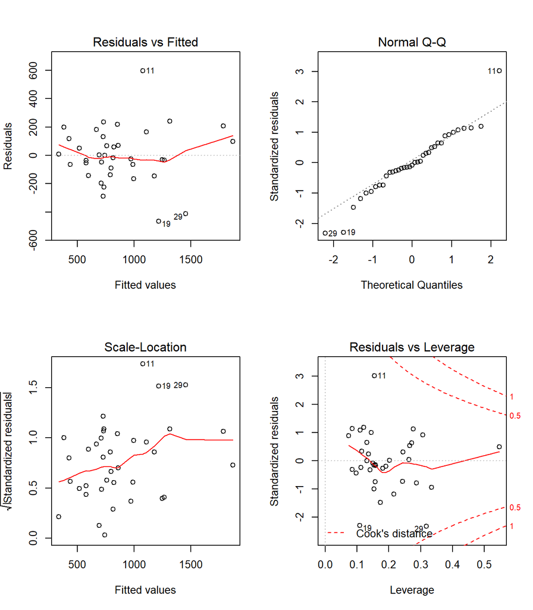

```r
par(mfrow=c(2,2))
plot(model_4)
```

```r
#Assess multicollinearity of chosen model
vif(model_4)
```

```
##      percent_m mean_education   police_exp60   unemploy_m39     inequality
##       1.871606       3.369039       1.917690       1.591097       3.370508
##    prob_prison
##       1.355172
```

Since there is no significant multicollinearity, no independent variables need to be further removed from the model.

## LBB Task

Learn by Building  
Write a regression analysis report applying what you’ve learned in the workshop. Using crime dataset provided, write your findings on the different socioeconomic variables most highly correlated to crime rates (crime_rate as dependent variable). Please knit your report into HTML.

Explain your recommendations where appropriate.

To help you through the exercise, you should ask the following questions of your candidate model:

```
1. Can you simplified your model without losing substantial information?
2. Did you use validation techniques such as train and test set?
4. Did you identify any violation of linear regression with diagnostic plots?
```

Point will be awarded if the followings are demonstrated:

```
1. Use of stepwise or regsubset techniques in model selection.
2. Perform simple diagnostic check on regression linear assumptions (Linearity, Multicolinearity, Heteroscedasticity, Normality)
3. Explain your model results such coefficients, R-square, RMSE etc.
```

## Full Code

```r
library(MASS)
library(GGally)
library(caret)
library(leaps)
library(car)
library(skimr)

data("UScrime")
crime <-  UScrime

names(crime) <- c("percent_m", "is_south", "mean_education", "police_exp60", "police_exp59", "labour_participation", "m_per1000f", "state_pop", "nonwhites_per1000", "unemploy_m24", "unemploy_m39", "gdp", "inequality", "prob_prison", "time_prison", "crime_rate")

#load and check data
str(crime)
#check for missing values
summary(crime)
#check correlations
ggcorr(crime, label = T, layout.exp = 1, cex=2.5)

set.seed(123)
sample_crime <- sample(nrow(crime), nrow(crime)*0.8)
train_crime <- crime[sample_crime,]
test_crime <- crime[-sample_crime,]

#check train and test datasets size
dim(train_crime)
dim(test_crime)
dim(crime)

#Base linear model
base_model <- lm(crime_rate ~., train_crime)
summary(base_model)

#prediction using model
predict_1 <- predict(base_model, test_crime)
#comparing actual against prediction values
data.frame(predict_1,test_crime$crime_rate)

#R squared(how correlated predicted and actual values are, the higher the better)
r_1 <- R2(predict_1, test_crime$crime_rate)

#rmse(error rate; avg diff btw predicted and actual values, the lower the better)
rmse_1 <- RMSE(predict_1, test_crime$crime_rate)

#Stepwise method to choose combination with least sum of residuals squared
step_both <- step(base_model, direction = "both")
step_both$call

model_2 <- lm(formula = crime_rate ~ percent_m + is_south + mean_education +
    police_exp60 + m_per1000f + unemploy_m24 + unemploy_m39 +
    inequality + prob_prison, data = train_crime)

summary(model_2)

predict_2 <- predict(model_2, test_crime)
data.frame(predict_2,test_crime$crime_rate)

#R squared
r_2 <- R2(predict_2, test_crime$crime_rate)

#rmse
rmse_2 <- RMSE(predict_2, test_crime$crime_rate)

#Adjusted R squared of model has improved from the base model and its p-value is <0.05, hence it is statistically significant. Variable is_south has a p-value >0.05, hence we should try removing it from model.

#try removing variable is_south since it is not significant and generate another model
model_3 <- lm(formula = crime_rate ~ percent_m + mean_education +
    police_exp60 + m_per1000f + unemploy_m24 + unemploy_m39 +
    inequality + prob_prison, data = train_crime)

summary(model_3)

predict_3 <- predict(model_3, test_crime)
data.frame(predict_3,test_crime$crime_rate)

#R squared
r_3 <- R2(predict_3, test_crime$crime_rate)

#rmse
rmse_3 <- RMSE(predict_3, test_crime$crime_rate)

#Adjusted R squared of model has dropped slightly, however p-value shows it is still statistically significant.
#Hence, this model is still a good fit for the data.
#As the drop in value is small and there is one less variable in the model,
#this model is simpler and should be kept for further evaluation.

#Best subset regression
lm_all <- regsubsets(crime_rate ~., crime, nvmax=16)
crime_subset <- summary(lm_all)

which.min(crime_subset$bic)

subsets(lm_all, statistic = "bic", legend = F, cex.subsets= 0.8, min.size = 5)

model_4 <- lm(crime_rate ~ percent_m + mean_education + police_exp60 + unemploy_m39 + inequality + prob_prison, data = train_crime)
summary(model_4)

predict_4 <- predict(model_4, test_crime)
data.frame(predict_4,test_crime$crime_rate)

#R squared
r_4 <- R2(predict_4, test_crime$crime_rate)

#rmse
rmse_4 <- RMSE(predict_4, test_crime$crime_rate)

#Adjusted R squared is 0.7203 and p-value shows it is statistically significant.
#Model should be considered for further evaluation.

#try removing variable unemploy_m39 as it seems statistically insignificant in model_4 and generate another model
model_5 <- lm(formula = crime_rate ~ percent_m + mean_education + police_exp60 + inequality + prob_prison, data = train_crime)

summary(model_5)

predict_5 <- predict(model_5, test_crime)
data.frame(predict_5, test_crime$crime_rate)

#R squared
r_5 <- R2(predict_5, test_crime$crime_rate)

#rmse
rmse_5 <- RMSE(predict_5, test_crime$crime_rate)

#Adjusted R squared is 0.7044 and p-value shows it is statistically significant.
#Model should be considered for further evaluation.

#Compare models
r_all <- c(r_1, r_2, r_3, r_4, r_5)
rmse_all <- c(rmse_1, rmse_2, rmse_3, rmse_4, rmse_5)
name <- c("Base Model", "Model 2", "Model 3", "Model 4", "Model 5")
kable(data.frame(name,"R squared" = r_all,"RMSE" = rmse_all))

#plot diagnostic graphs
par(mfrow=c(2,2))
plot(model_4)

#Assess multicollinearity of chosen model
vif(model_4)
```

# Findings

Model 4 has 6 predictors considered in the regression model: `percent_m`, `mean_education`, `police_exp60`, `unemploy_m39`, `inequality` and `prob_prison`.  
Model 4 is the best model thus far as it has the highest R squared and lowest RMSE values compared to the other models. Furthermore, diagnostic checks done showed that the model follows the assumptions of linearity and normality. There is also no presence of influential outlier cases. However, heteroscedasticity is a problem. Perhaps, more can be done to investigate and transform the variable(s) which cause this problem before generating another regression model. Another problem is the small dataset. There is only 47 observations in the data which makes the model more prone to problems such as overfitting and outliers being influential.